# Event Boundaries and Recognition Memory

BRSM 2026 — Mnemonic Similarity Task · Team 17

D. Subhash Chandra · T. Sathvik Reddy · Y. Havinash Reddy

06 May 2026

# 1 Setup

## 1.2 Load Libraries

```r
library(tidyverse)
library(knitr)
library(kableExtra)
library(rstatix)
library(coin)
```

## 1.3 Configuration

**Set `DATA_DIR` to the path of your `MST_Data` folder.** The `.Rmd` file and `MST_Data/` folder should be in the same working directory.

```r
DATA_DIR <- "D:/IIITH_SEMESTER2/BRSM/MST_Exp/MST_Data"

PATHS <- list(
  both      = file.path(DATA_DIR, "Both_item_task",  "both_data"),
  item_only = file.path(DATA_DIR, "item_only",       "item_only_data"),
  task_only = file.path(DATA_DIR, "task_only",       "task_only_data")
)

OUTPUT_DIR <- "outputs"
dir.create(OUTPUT_DIR, showWarnings = FALSE)

ALPHA      <- 0.05
ALPHA_BONF <- 0.05 / 4   # Bonferroni threshold for Phase 1 primary tests
```

# 2 Introduction

## 2.1 Background

We experience life as a continuous stream of events, yet our minds naturally divide this stream into meaningful chunks separated by **event boundaries** — moments when one situation ends and another begins (Zacks et al., 2007). According to Event Segmentation Theory (EST), the cognitive system continuously maintains a predictive model of the current situation. When predictions fail — a new location, a new person, a new task — the system detects a boundary, consolidates the current event into long-term memory, and resets to begin encoding the incoming one. This consolidation at the moment of transition is theorised to leave a brief attentional gap for the very first item of the new event.

Memory for individual events is shaped not only by overall attention but by hippocampal **pattern separation** — the ability to store similar experiences as non-overlapping neural traces (Yassa & Stark, 2011). The **Mnemonic Similarity Task (MST)** (Stark et al., 2019) exploits this property by presenting three types of test stimuli:

- **Targets** — exact repeats of studied images; tests basic recognition
- **Lures** — perceptually similar but not identical to studied items; tests mnemonic discrimination via pattern separation
- **Foils** — entirely novel images; provides a false-alarm baseline

Lures are graded across **5 similarity bins** (Bin 1 = most similar to target, Bin 5 = least similar), enabling a fine-grained characterisation of pattern separation capacity.

## 2.2 The Present Study

Morse et al. (2023) were the first to combine event boundaries with the MST. They found a striking directional asymmetry:

- Items encoded **immediately after** a boundary (Post-Boundary) showed *impaired* target recognition.
- Items encoded **immediately before** a boundary (Pre-Boundary) showed *enhanced* lure discrimination.

They attributed this to hippocampal snapshot encoding at event offsets: resources devoted to consolidating the ending event reduce encoding capacity for the first item of the incoming event, while the anticipatory state just before a boundary enhances fine-grained mnemonic discrimination.

The present study replicates Morse et al. (2023) with three between-subjects groups, each experiencing a *different type* of event boundary, to isolate what component of a boundary is actually driving the memory effects:

| Group | Boundary Type | n |
| --- | --- | --- |
| **Both** | Item class shift (Objects vs. Scenes) + task question shift | 52 |
| **Item-Only** | Item class shift only | 56 |
| **Task-Only** | Task question shift only | 53 |

Key design differences from the original: (i) the object encoding question was changed to *“Will it fit in a shoebox?”*; (ii) events consisted of 7 images per block across 40 events (280 encoding trials total); (iii) the recognition test used a three-response format (*old / new / similar*) with 60 Targets, 60 Lures, and 30 Foils.

## 2.3 Hypotheses

**H1a** — Post-Boundary items will show impaired target recognition (REC) relative to the Mid-Boundary baseline, primarily in the Both group.

**H1b** — Pre-Boundary items will show enhanced lure discrimination (LDI) relative to the Mid-Boundary baseline, primarily in the Both group.

Item-Only and Task-Only groups are expected to show weaker or absent effects, as they lack one component of the compound boundary.

## 2.4 Key Measures

$$\text{REC} = P(\text{"old"}
\mid \text{Target}) - P(\text{"old"} \mid
\text{Foil})$$

$$\text{LDI} =
P(\text{"similar"} \mid \text{Lure}) -
P(\text{"similar"} \mid \text{Foil})$$

Both indices subtract each participant’s Foil false-alarm rate to correct for individual response bias. Values above zero indicate above-chance performance; values at or below zero indicate chance-level or impaired performance. Difference scores are computed as: Boundary position score − Mid-Boundary score.

# 3 Methods

## 3.1 Data Loading and Organisation

### 3.1.1 Parsing the Test File

Each participant contributes one test CSV (150 rows). Key columns:

| Column | Meaning |
| --- | --- |
| `image_path` | `a.jpg` = Target, `b.jpg` = Lure, `Foil/` prefix = Foil |
| `trials.key_resp_3.keys` | Response: `o` = old, `n` = new, `s` = similar |
| `position_of_stimuli` | `post`, `pre`, `mid`, or `none` (Foils) |

```r
# Load bin mapping files (used for lure bin analysis in Section 6)
bin_map_obj <- read.table(
  file.path(PATHS$both, "..", "Set6 bins.txt"),
  col.names = c("id", "bin"))
bin_map_scn <- read.table(
  file.path(PATHS$both, "..", "SetScC bins.txt"),
  col.names = c("id", "bin"))

parse_test_file <- function(filepath, group_label) {
  raw <- read_csv(filepath, show_col_types = FALSE)
  pid <- tools::file_path_sans_ext(basename(filepath))

  raw %>%
    filter(!is.na(image_path)) %>%
    mutate(
      image_path = str_trim(image_path),
      img_id   = as.integer(str_extract(basename(image_path), "\\d+")),
      img_type = case_when(
        str_detect(image_path, regex("Object", ignore_case = TRUE)) ~ "Object",
        str_detect(image_path, regex("Scene",  ignore_case = TRUE)) ~ "Scene",
        TRUE ~ "Unknown"
      )
    ) %>%
    left_join(bin_map_obj, by = c("img_id" = "id")) %>% rename(bin_obj = bin) %>%
    left_join(bin_map_scn, by = c("img_id" = "id")) %>% rename(bin_scn = bin) %>%
    transmute(
      participant  = pid,
      group        = group_label,
      image_path,
      stim_type = case_when(
        str_detect(image_path, regex("Foil", ignore_case = TRUE)) ~ "Foil",
        str_ends(image_path, "b.jpg")                              ~ "Lure",
        str_ends(image_path, "a.jpg")                              ~ "Target",
        TRUE ~ NA_character_
      ),
      img_type,
      lure_bin = case_when(
        stim_type == "Lure" & img_type == "Object" ~ bin_obj,
        stim_type == "Lure" & img_type == "Scene"  ~ bin_scn,
        TRUE ~ NA_integer_
      ),
      response = case_when(
        `trials.key_resp_3.keys` == "o" ~ "old",
        `trials.key_resp_3.keys` == "n" ~ "new",
        `trials.key_resp_3.keys` == "s" ~ "similar",
        TRUE ~ NA_character_
      ),
      RT_ms        = `trials.key_resp_3.rt` * 1000,
      boundary_pos = case_when(
        position_of_stimuli == "post" ~ "Post-Boundary",
        position_of_stimuli == "pre"  ~ "Pre-Boundary",
        position_of_stimuli == "mid"  ~ "Mid-Boundary",
        TRUE ~ NA_character_
      ),
      boundary_pos = factor(boundary_pos,
                            levels = c("Post-Boundary", "Mid-Boundary", "Pre-Boundary"))
    ) %>%
    filter(!is.na(stim_type))
}
```

### 3.1.2 Parsing the Encoding (Task) File

Each participant also has one task CSV (280 encoding trials). Reaction time is corrected as: if the participant responded *before* the image disappeared, `key_resp_9.rt` records the RT; if they responded *after* (image shown for 3 s), total RT = 3 + `key_resp_8.rt`. Four files were missing `key_resp_8.rt` (participants who always responded within the display window) — these columns were added as NA prior to processing to prevent a pipeline crash.

```r
parse_task_file <- function(filepath, group_label) {
  raw <- read_csv(filepath, show_col_types = FALSE)
  pid <- tools::file_path_sans_ext(basename(filepath))

  if (!"trials.key_resp_8.rt" %in% names(raw)) raw$trials.key_resp_8.rt <- NA_real_
  if (!"trials.key_resp_9.rt" %in% names(raw)) raw$trials.key_resp_9.rt <- NA_real_

  raw %>%
    filter(!is.na(trials.thisN),
           !str_detect(image_path, regex("practice", ignore_case = TRUE))) %>%
    transmute(
      participant = pid,
      group       = group_label,
      trial_n     = as.integer(trials.thisN),
      image_path  = str_trim(image_path),
      img_type = case_when(
        str_detect(image_path, regex("Object", ignore_case = TRUE)) ~ "Object",
        str_detect(image_path, regex("Scene",  ignore_case = TRUE)) ~ "Scene",
        TRUE ~ "Unknown"
      ),
      RT_ms = case_when(
        !is.na(`trials.key_resp_9.rt`) ~ as.numeric(`trials.key_resp_9.rt`) * 1000,
        !is.na(`trials.key_resp_8.rt`) ~ (3 + as.numeric(`trials.key_resp_8.rt`)) * 1000,
        TRUE ~ NA_real_
      )
    ) %>%
    arrange(trial_n) %>%
    mutate(
      pos_in_event = trial_n %% 7L,
      boundary_pos = case_when(
        pos_in_event == 0 ~ "Post-Boundary",
        pos_in_event == 6 ~ "Pre-Boundary",
        TRUE              ~ "Mid-Boundary"
      ),
      boundary_pos = factor(boundary_pos,
                            levels = c("Post-Boundary", "Mid-Boundary", "Pre-Boundary"))
    )
}
```

### 3.1.3 Load All Participants

```r
load_group <- function(folder, group_label, type = c("task", "test")) {
  type    <- match.arg(type)
  pattern <- if (type == "task") "MST_task.*\\.csv$" else "MST_test.*\\.csv$"
  parser  <- if (type == "task") parse_task_file else parse_test_file
  files   <- list.files(folder, pattern = pattern, full.names = TRUE)
  map_dfr(files, ~ parser(.x, group_label))
}

test_data <- bind_rows(
  load_group(PATHS$both,      "Both",      "test"),
  load_group(PATHS$item_only, "Item-Only", "test"),
  load_group(PATHS$task_only, "Task-Only", "test")
) %>% mutate(group = factor(group, levels = c("Item-Only", "Task-Only", "Both")))

encoding_data <- bind_rows(
  load_group(PATHS$both,      "Both",      "task"),
  load_group(PATHS$item_only, "Item-Only", "task"),
  load_group(PATHS$task_only, "Task-Only", "task")
) %>% mutate(group = factor(group, levels = c("Item-Only", "Task-Only", "Both")))

test_data %>%
  distinct(participant, group) %>%
  count(group, name = "N_participants") %>%
  kable(caption = "Participants loaded per group") %>%
  kable_styling(bootstrap_options = c("striped", "hover"), full_width = FALSE) %>%
  row_spec(0, bold = TRUE, background = "#2E5FA3", color = "white")
```

Participants loaded per group

| group | N_participants |
| --- | --- |
| Item-Only | 56 |
| Task-Only | 53 |
| Both | 52 |

## 3.2 Computing REC and LDI

```r
# Step 1: Foil false-alarm rates per participant
foil_rates <- test_data %>%
  filter(stim_type == "Foil") %>%
  group_by(participant, group) %>%
  summarise(p_old_foil = mean(response == "old",     na.rm = TRUE),
            p_sim_foil = mean(response == "similar", na.rm = TRUE),
            .groups = "drop")

# Step 2: Target hit rates and lure "similar" rates by boundary position
target_rates <- test_data %>%
  filter(stim_type == "Target", !is.na(boundary_pos)) %>%
  group_by(participant, group, boundary_pos) %>%
  summarise(p_old_target = mean(response == "old", na.rm = TRUE), .groups = "drop")

lure_rates <- test_data %>%
  filter(stim_type == "Lure", !is.na(boundary_pos)) %>%
  group_by(participant, group, boundary_pos) %>%
  summarise(p_sim_lure = mean(response == "similar", na.rm = TRUE), .groups = "drop")

# Step 3: Merge and compute bias-corrected scores
scores <- target_rates %>%
  full_join(lure_rates, by = c("participant", "group", "boundary_pos")) %>%
  left_join(foil_rates, by = c("participant", "group")) %>%
  mutate(REC = p_old_target - p_old_foil,
         LDI = p_sim_lure   - p_sim_foil)

# Step 4: Difference scores relative to Mid-Boundary baseline
mid_scores <- scores %>%
  filter(boundary_pos == "Mid-Boundary") %>%
  select(participant, group, REC_mid = REC, LDI_mid = LDI)

diff_scores <- scores %>%
  filter(boundary_pos != "Mid-Boundary") %>%
  left_join(mid_scores, by = c("participant", "group")) %>%
  mutate(REC_diff = REC - REC_mid,
         LDI_diff = LDI - LDI_mid)
```

# 4 Results — Part 1: Descriptive Statistics and Initial Tests

## 4.1 Raw Response Proportions

Before computing bias-corrected indices, we examine raw response proportions to get a first sense of the data.

```r
raw_rates <- test_data %>%
  filter(!is.na(boundary_pos) | stim_type == "Foil") %>%
  mutate(pos_label = ifelse(stim_type == "Foil", "Foil", as.character(boundary_pos))) %>%
  group_by(group, stim_type, pos_label) %>%
  summarise(N       = n(),
            pct_old = round(mean(response == "old",     na.rm = TRUE), 3),
            pct_new = round(mean(response == "new",     na.rm = TRUE), 3),
            pct_sim = round(mean(response == "similar", na.rm = TRUE), 3),
            .groups = "drop") %>%
  filter(!(stim_type == "Foil" & pos_label != "Foil"))

raw_rates %>%
  arrange(group, stim_type, pos_label) %>%
  kable(caption = "Table 1. Mean response proportions by stimulus type, boundary position, and group.",
        col.names = c("Group", "Stim Type", "Position", "N",
                      "P(old)", "P(new)", "P(similar)")) %>%
  kable_styling(bootstrap_options = c("striped", "hover", "bordered"), full_width = TRUE) %>%
  row_spec(0, bold = TRUE, background = "#2E5FA3", color = "white")
```

Table 1. Mean response proportions by stimulus type, boundary position, and group.

| Group | Stim Type | Position | N | P(old) | P(new) | P(similar) |
| --- | --- | --- | --- | --- | --- | --- |
| Item-Only | Foil | Foil | 1680 | 0.035 | 0.775 | 0.190 |
| Item-Only | Lure | Mid-Boundary | 1120 | 0.286 | 0.195 | 0.520 |
| Item-Only | Lure | Post-Boundary | 1120 | 0.284 | 0.212 | 0.504 |
| Item-Only | Lure | Pre-Boundary | 1120 | 0.299 | 0.197 | 0.504 |
| Item-Only | Target | Mid-Boundary | 1120 | 0.675 | 0.096 | 0.229 |
| Item-Only | Target | Post-Boundary | 1120 | 0.670 | 0.095 | 0.236 |
| Item-Only | Target | Pre-Boundary | 1120 | 0.662 | 0.103 | 0.235 |
| Task-Only | Foil | Foil | 1590 | 0.031 | 0.775 | 0.194 |
| Task-Only | Lure | Mid-Boundary | 1060 | 0.258 | 0.180 | 0.562 |
| Task-Only | Lure | Post-Boundary | 1060 | 0.235 | 0.186 | 0.579 |
| Task-Only | Lure | Pre-Boundary | 1060 | 0.250 | 0.169 | 0.581 |
| Task-Only | Target | Mid-Boundary | 1060 | 0.632 | 0.098 | 0.270 |
| Task-Only | Target | Post-Boundary | 1060 | 0.594 | 0.113 | 0.292 |
| Task-Only | Target | Pre-Boundary | 1060 | 0.656 | 0.097 | 0.247 |
| Both | Foil | Foil | 1560 | 0.047 | 0.754 | 0.199 |
| Both | Lure | Mid-Boundary | 1040 | 0.289 | 0.228 | 0.483 |
| Both | Lure | Post-Boundary | 1040 | 0.301 | 0.249 | 0.450 |
| Both | Lure | Pre-Boundary | 1040 | 0.326 | 0.210 | 0.464 |
| Both | Target | Mid-Boundary | 1040 | 0.668 | 0.108 | 0.224 |
| Both | Target | Post-Boundary | 1040 | 0.596 | 0.144 | 0.260 |
| Both | Target | Pre-Boundary | 1040 | 0.651 | 0.090 | 0.259 |

### 4.1.1 Figure 1: Response Proportions by Stimulus Type

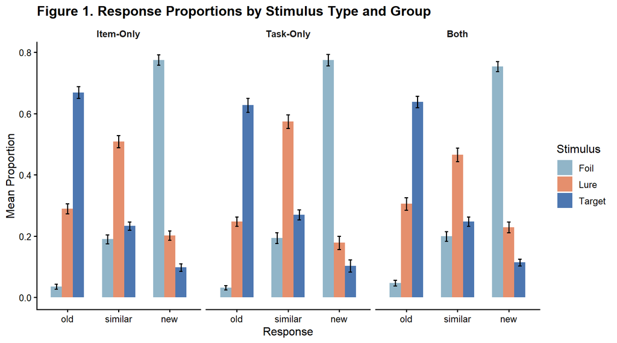

Figure 1. Mean proportion of each response type by stimulus type and group. Error bars = ±1 SE.

```r
resp_clean <- test_data %>%
  filter(!is.na(response)) %>%
  group_by(participant, group, stim_type) %>%
  summarise(old     = mean(response == "old"),
            new     = mean(response == "new"),
            similar = mean(response == "similar"),
            .groups = "drop") %>%
  pivot_longer(cols = c(old, new, similar),
               names_to = "response", values_to = "prop")

resp_se <- resp_clean %>%
  group_by(group, stim_type, response) %>%
  summarise(M = mean(prop), SE = sd(prop)/sqrt(n()), .groups = "drop") %>%
  mutate(response = factor(response, levels = c("old", "similar", "new")))

fig1 <- resp_se %>%
  ggplot(aes(x = response, y = M, fill = stim_type)) +
  geom_col(position = "dodge", alpha = 0.85, width = 0.65) +
  geom_errorbar(aes(ymin = M - SE, ymax = M + SE),
                position = position_dodge(0.65), width = 0.2) +
  scale_fill_manual(values = c("Target" = "#2E5FA3",
                               "Lure"   = "#E07B54",
                               "Foil"   = "#7EA8BE"),
                    name = "Stimulus") +
  facet_wrap(~group) +
  labs(x = "Response", y = "Mean Proportion",
       title = "Figure 1. Response Proportions by Stimulus Type and Group") +
  theme_classic(base_size = 12) +
  theme(strip.background = element_blank(),
        strip.text        = element_text(face = "bold"),
        plot.title        = element_text(face = "bold"))

fig1
```

```r
ggsave(file.path(OUTPUT_DIR, "fig1_response_proportions.png"),
       fig1, width = 9, height = 4, dpi = 300)
```

## 4.2 Descriptive Statistics: REC and LDI

```r
desc <- scores %>%
  group_by(group, boundary_pos) %>%
  summarise(N      = n(),
            REC_M  = round(mean(REC, na.rm = TRUE), 3),
            REC_SD = round(sd(REC,   na.rm = TRUE), 3),
            LDI_M  = round(mean(LDI, na.rm = TRUE), 3),
            LDI_SD = round(sd(LDI,   na.rm = TRUE), 3),
            .groups = "drop")

desc %>%
  kable(caption = "Table 2. Descriptive statistics for REC and LDI by group and boundary position.",
        col.names = c("Group", "Boundary Position", "N",
                      "REC Mean", "REC SD", "LDI Mean", "LDI SD")) %>%
  kable_styling(bootstrap_options = c("striped", "hover", "bordered"), full_width = TRUE) %>%
  row_spec(0, bold = TRUE, background = "#2E5FA3", color = "white")
```

Table 2. Descriptive statistics for REC and LDI by group and boundary position.

| Group | Boundary Position | N | REC Mean | REC SD | LDI Mean | LDI SD |
| --- | --- | --- | --- | --- | --- | --- |
| Item-Only | Post-Boundary | 56 | 0.635 | 0.188 | 0.314 | 0.172 |
| Item-Only | Mid-Boundary | 56 | 0.640 | 0.178 | 0.330 | 0.188 |
| Item-Only | Pre-Boundary | 56 | 0.627 | 0.157 | 0.314 | 0.213 |
| Task-Only | Post-Boundary | 53 | 0.563 | 0.204 | 0.386 | 0.229 |
| Task-Only | Mid-Boundary | 53 | 0.601 | 0.183 | 0.369 | 0.180 |
| Task-Only | Pre-Boundary | 53 | 0.624 | 0.195 | 0.387 | 0.205 |
| Both | Post-Boundary | 52 | 0.549 | 0.164 | 0.251 | 0.185 |
| Both | Mid-Boundary | 52 | 0.621 | 0.175 | 0.283 | 0.221 |
| Both | Pre-Boundary | 52 | 0.604 | 0.155 | 0.265 | 0.184 |

```r
write_csv(desc, file.path(OUTPUT_DIR, "table2_descriptive_REC_LDI.csv"))
```

### 4.2.1 Figure 2: Target Hit Rates by Boundary Position

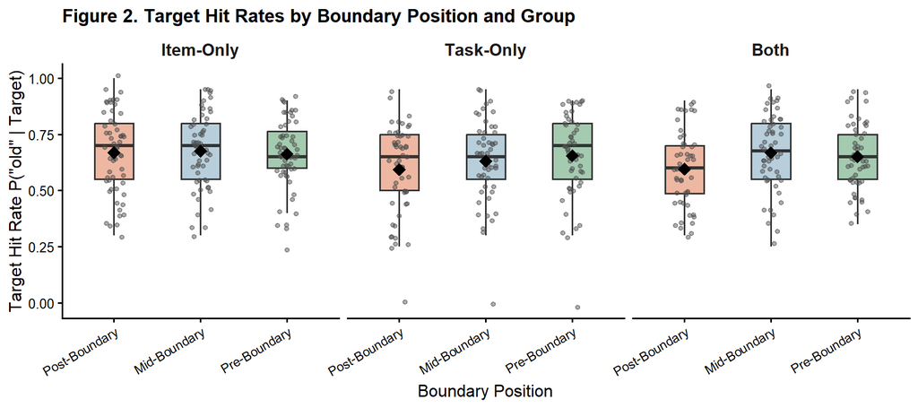

Figure 2. Target hit rate by boundary position and group. Diamonds = group means; dots = individual participants.

```r
fig2 <- scores %>%
  ggplot(aes(x = boundary_pos, y = p_old_target, fill = boundary_pos)) +
  geom_boxplot(outlier.shape = NA, alpha = 0.55, width = 0.45) +
  geom_jitter(width = 0.12, alpha = 0.45, size = 1.3, colour = "grey30") +
  stat_summary(fun = mean, geom = "point", shape = 18, size = 4, colour = "black") +
  scale_fill_manual(values = bp_col) +
  facet_wrap(~group) +
  labs(x = "Boundary Position", y = "Target Hit Rate P(\"old\" | Target)",
       title = "Figure 2. Target Hit Rates by Boundary Position and Group") +
  theme_mst +
  theme(axis.text.x = element_text(angle = 30, hjust = 1, size = 9))

fig2
```

```r
ggsave(file.path(OUTPUT_DIR, "fig2_target_hit_rates.png"),
       fig2, width = 9, height = 3.8, dpi = 300)
```

### 4.2.2 Figure 3: Lure Discrimination Rates by Boundary Position

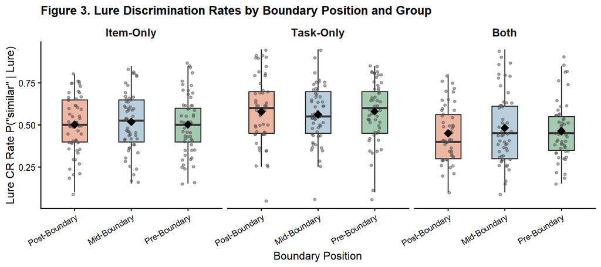

Figure 3. Proportion of ‘similar’ responses to Lures by boundary position and group. Higher values reflect better mnemonic discrimination.

```r
fig3 <- scores %>%
  ggplot(aes(x = boundary_pos, y = p_sim_lure, fill = boundary_pos)) +
  geom_boxplot(outlier.shape = NA, alpha = 0.55, width = 0.45) +
  geom_jitter(width = 0.12, alpha = 0.45, size = 1.3, colour = "grey30") +
  stat_summary(fun = mean, geom = "point", shape = 18, size = 4, colour = "black") +
  scale_fill_manual(values = bp_col) +
  facet_wrap(~group) +
  labs(x = "Boundary Position", y = "Lure CR Rate P(\"similar\" | Lure)",
       title = "Figure 3. Lure Discrimination Rates by Boundary Position and Group") +
  theme_mst +
  theme(axis.text.x = element_text(angle = 30, hjust = 1, size = 9))

fig3
```

```r
ggsave(file.path(OUTPUT_DIR, "fig3_lure_sim_rates.png"),
       fig3, width = 9, height = 3.8, dpi = 300)
```

### 4.2.3 Figure 4: Bias-Corrected REC and LDI

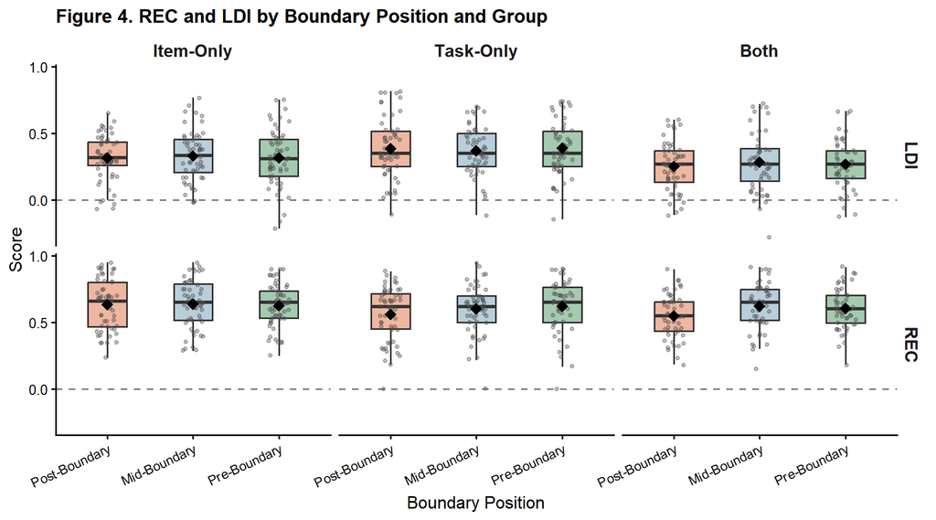

Figure 4. Bias-corrected REC and LDI scores by boundary position and group. Dashed line = zero. Diamond = group mean.

```r
scores_long <- scores %>%
  select(participant, group, boundary_pos, REC, LDI) %>%
  pivot_longer(cols = c(REC, LDI), names_to = "Measure", values_to = "Score")

fig4 <- scores_long %>%
  ggplot(aes(x = boundary_pos, y = Score, fill = boundary_pos)) +
  geom_hline(yintercept = 0, linetype = "dashed", colour = "grey50") +
  geom_boxplot(outlier.shape = NA, alpha = 0.55, width = 0.45) +
  geom_jitter(width = 0.12, alpha = 0.35, size = 1.0, colour = "grey30") +
  stat_summary(fun = mean, geom = "point", shape = 18, size = 3.5, colour = "black") +
  scale_fill_manual(values = bp_col) +
  facet_grid(Measure ~ group) +
  labs(x = "Boundary Position", y = "Score",
       title = "Figure 4. REC and LDI by Boundary Position and Group") +
  theme_mst +
  theme(axis.text.x = element_text(angle = 25, hjust = 1, size = 9))

fig4
```

```r
ggsave(file.path(OUTPUT_DIR, "fig4_REC_LDI_scores.png"),
       fig4, width = 9, height = 5, dpi = 300)
```

## 4.3 Encoding RT: Manipulation Check

Before testing memory effects, we first confirm that participants *actually perceived* the event boundaries as genuine transitions. If they did, encoding reaction times should slow down immediately after a boundary — reflecting the cognitive cost of updating the mental event model (Radvansky, 2017). Without this manipulation check, any memory differences between boundary positions could simply reflect differences in how the stimuli were encoded rather than a true boundary effect.

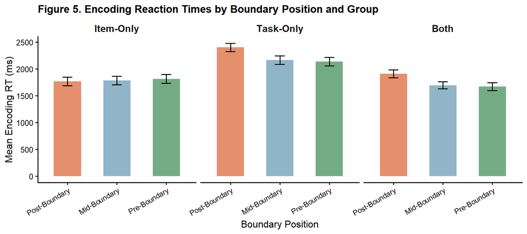

Figure 5. Mean encoding RT (ms) by boundary position and group. Error bars = ±1 SE. A Post-Boundary slowdown is evidence that participants perceived the event transition.

```r
rt_summary <- encoding_data %>%
  group_by(participant, group, boundary_pos) %>%
  summarise(mean_RT = mean(RT_ms, na.rm = TRUE), .groups = "drop") %>%
  group_by(group, boundary_pos) %>%
  summarise(M  = mean(mean_RT, na.rm = TRUE),
            SE = sd(mean_RT,   na.rm = TRUE) / sqrt(n()),
            .groups = "drop")

fig5 <- rt_summary %>%
  ggplot(aes(x = boundary_pos, y = M, fill = boundary_pos)) +
  geom_col(alpha = 0.85, width = 0.55) +
  geom_errorbar(aes(ymin = M - SE, ymax = M + SE), width = 0.2) +
  scale_fill_manual(values = bp_col) +
  facet_wrap(~group) +
  labs(x = "Boundary Position", y = "Mean Encoding RT (ms)",
       title = "Figure 5. Encoding Reaction Times by Boundary Position and Group") +
  theme_mst +
  theme(axis.text.x = element_text(angle = 30, hjust = 1, size = 9))

fig5
```

```r
ggsave(file.path(OUTPUT_DIR, "fig5_encoding_RT.png"),
       fig5, width = 9, height = 3.8, dpi = 300)
```

The encoding RT data confirm that participants in the Both and Task-Only groups genuinely perceived the event transitions. The Both group showed a clear Post-Boundary slowdown (~1,908 ms) relative to Mid-Boundary (~1,691 ms), a difference of approximately 217 ms. Task-Only showed a similar pattern (~2,399 ms Post vs. ~2,164 ms Mid, +235 ms). In contrast, Item-Only showed virtually no Post-Boundary increase (~1,767 ms Post vs. ~1,783 ms Mid, −16 ms), indicating that a stimulus class shift alone — without a task change — was not perceived as a functional event boundary. This dissociation is important: it means that any subsequent memory effects in the Both and Task-Only groups are grounded in a genuine perceptual boundary experience, while Item-Only’s null memory results are consistent with the absence of a perceived boundary.

## 4.4 One-Sample t-Tests: Did Boundary Position Affect Memory?

The descriptive data and visualisations suggest a Post-Boundary dip in REC in the Both group. To test this formally, we ask whether each group’s mean *difference score* (boundary position − Mid-Boundary baseline) deviates from zero. A negative difference for Post-Boundary REC means recognition was worse than baseline; a positive difference for Pre-Boundary LDI means discrimination was better than baseline.

We use one-sample t-tests with directional alternatives (Post REC < 0; Pre LDI > 0) and apply Bonferroni correction across the four primary tests (α = 0.05/4 = **0.0125**), as only the Both group was predicted *a priori* to show effects. Results for Item-Only and Task-Only are exploratory.

### 4.4.1 Assumption Check: Normality of Difference Scores

Before running the t-tests, we verify that the difference scores are approximately normally distributed using the **Shapiro-Wilk test** (null hypothesis: data are normally distributed). A p-value > 0.05 indicates no significant departure from normality. Because the one-sample t-test is reasonably robust to mild non-normality at n ≥ 30 (Central Limit Theorem), we proceed with t-tests even if individual cells show minor violations, but flag any serious departures.

```r
# Shapiro-Wilk on the four primary difference scores (Post-Boundary REC and Pre-Boundary LDI)
sw_phase1 <- bind_rows(
  diff_scores %>%
    filter(boundary_pos == "Post-Boundary") %>%
    group_by(group) %>%
    summarise(
      Measure  = "REC",
      Position = "Post-Boundary",
      N        = sum(!is.na(REC_diff)),
      W        = round(shapiro.test(REC_diff)$statistic, 3),
      p        = round(shapiro.test(REC_diff)$p.value,   4),
      .groups  = "drop"
    ),
  diff_scores %>%
    filter(boundary_pos == "Pre-Boundary") %>%
    group_by(group) %>%
    summarise(
      Measure  = "LDI",
      Position = "Pre-Boundary",
      N        = sum(!is.na(LDI_diff)),
      W        = round(shapiro.test(LDI_diff)$statistic, 3),
      p        = round(shapiro.test(LDI_diff)$p.value,   4),
      .groups  = "drop"
    )
) %>%
  mutate(Normal = ifelse(p >= ALPHA, "Yes", "No *")) %>%
  select(group, Measure, Position, N, W, p, Normal)

sw_phase1 %>%
  kable(caption = "Table SW1. Shapiro-Wilk normality tests for Phase 1 difference scores.",
        col.names = c("Group", "Measure", "Position", "N", "W", "p", "Normal?")) %>%
  kable_styling(bootstrap_options = c("striped", "hover", "bordered"), full_width = TRUE) %>%
  row_spec(0, bold = TRUE, background = "#2E5FA3", color = "white") %>%
  row_spec(which(sw_phase1$Normal == "No *"), background = "#FDEBD0")
```

Table SW1. Shapiro-Wilk normality tests for Phase 1 difference scores.

| Group | Measure | Position | N | W | p | Normal? |
| --- | --- | --- | --- | --- | --- | --- |
| Item-Only | REC | Post-Boundary | 56 | 0.974 | 0.2545 | Yes |
| Task-Only | REC | Post-Boundary | 53 | 0.956 | 0.0504 | Yes |
| Both | REC | Post-Boundary | 52 | 0.980 | 0.5147 | Yes |
| Item-Only | LDI | Pre-Boundary | 56 | 0.962 | 0.0764 | Yes |
| Task-Only | LDI | Pre-Boundary | 53 | 0.942 | 0.0129 | No * |
| Both | LDI | Pre-Boundary | 52 | 0.961 | 0.0862 | Yes |

```r
n_violations <- sum(sw_phase1$Normal == "No *")
if (n_violations == 0) {
  cat("> **Normality assumption met** for all Phase 1 difference scores (all Shapiro-Wilk p > 0.05).
  One-sample t-tests are appropriate.\n")
} else {
  cat(paste0("> **", n_violations, " cell(s) show a significant departure from normality** (highlighted above).
  However, with n ≥ 52 per group, the one-sample t-test is robust to moderate non-normality
  by the Central Limit Theorem. Results are interpreted with appropriate caution.\n"))
}
```

> **1 cell(s) show a significant departure from normality** (highlighted above). However, with n ≥ 52 per group, the one-sample t-test is robust to moderate non-normality by the Central Limit Theorem. Results are interpreted with appropriate caution.

```r
run_ttest <- function(grp, measure, pos, data_col, direction = "two.sided") {
  x  <- diff_scores %>%
    filter(group == grp, boundary_pos == pos) %>%
    pull({{ data_col }})
  tt <- t.test(x, mu = 0, alternative = direction)
  tibble(
    Group     = grp,
    Measure   = measure,
    Position  = pos,
    N         = length(x[!is.na(x)]),
    Mean_Diff = round(mean(x, na.rm = TRUE), 3),
    SD        = round(sd(x,   na.rm = TRUE), 3),
    t         = round(tt$statistic,          3),
    df        = round(tt$parameter,          1),
    p         = round(tt$p.value,            4),
    CI_lower  = round(tt$conf.int[1],        3),
    CI_upper  = round(tt$conf.int[2],        3)
  )
}

results_p1 <- bind_rows(
  run_ttest("Both",      "REC", "Post-Boundary", REC_diff, "less"),
  run_ttest("Item-Only", "REC", "Post-Boundary", REC_diff, "less"),
  run_ttest("Task-Only", "REC", "Post-Boundary", REC_diff, "less"),
  run_ttest("Both",      "LDI", "Pre-Boundary",  LDI_diff, "greater"),
  run_ttest("Item-Only", "LDI", "Pre-Boundary",  LDI_diff, "greater"),
  run_ttest("Task-Only", "LDI", "Pre-Boundary",  LDI_diff, "greater")
) %>%
  mutate(Sig = ifelse(p < ALPHA_BONF, "Yes *", "No"))

results_p1 %>%
  kable(caption = paste0("Table 3. One-sample t-tests: difference scores vs. zero. ",
                         "Bonferroni-corrected α = ", ALPHA_BONF,
                         ". * = survives correction."),
        col.names = c("Group", "Measure", "Position", "N",
                      "Mean Diff", "SD", "t", "df", "p",
                      "95% CI Low", "95% CI High", "Sig.")) %>%
  kable_styling(bootstrap_options = c("striped", "hover", "bordered"), full_width = TRUE) %>%
  row_spec(0, bold = TRUE, background = "#2E5FA3", color = "white") %>%
  row_spec(which(results_p1$Sig == "Yes *"), background = "#E8F5E9", bold = TRUE)
```

Table 3. One-sample t-tests: difference scores vs. zero. Bonferroni-corrected α = 0.0125. * = survives correction.

| Group | Measure | Position | N | Mean Diff | SD | t | df | p | 95% CI Low | 95% CI High | Sig. |
| --- | --- | --- | --- | --- | --- | --- | --- | --- | --- | --- | --- |
| Both | REC | Post-Boundary | 52 | -0.072 | 0.150 | -3.468 | 51 | 0.0005 | -Inf | -0.037 | Yes * |
| Item-Only | REC | Post-Boundary | 56 | -0.005 | 0.161 | -0.249 | 55 | 0.4021 | -Inf | 0.031 | No |
| Task-Only | REC | Post-Boundary | 53 | -0.038 | 0.153 | -1.801 | 52 | 0.0387 | -Inf | -0.003 | No |
| Both | LDI | Pre-Boundary | 52 | -0.018 | 0.153 | -0.859 | 51 | 0.8028 | -0.054 | Inf | No |
| Item-Only | LDI | Pre-Boundary | 56 | -0.016 | 0.144 | -0.833 | 55 | 0.7959 | -0.048 | Inf | No |
| Task-Only | LDI | Pre-Boundary | 53 | 0.019 | 0.138 | 0.992 | 52 | 0.1628 | -0.013 | Inf | No |

```r
write_csv(results_p1, file.path(OUTPUT_DIR, "table3_hypothesis_tests.csv"))
```

### 4.4.2 Figure 6: Difference Scores with Significance Annotations

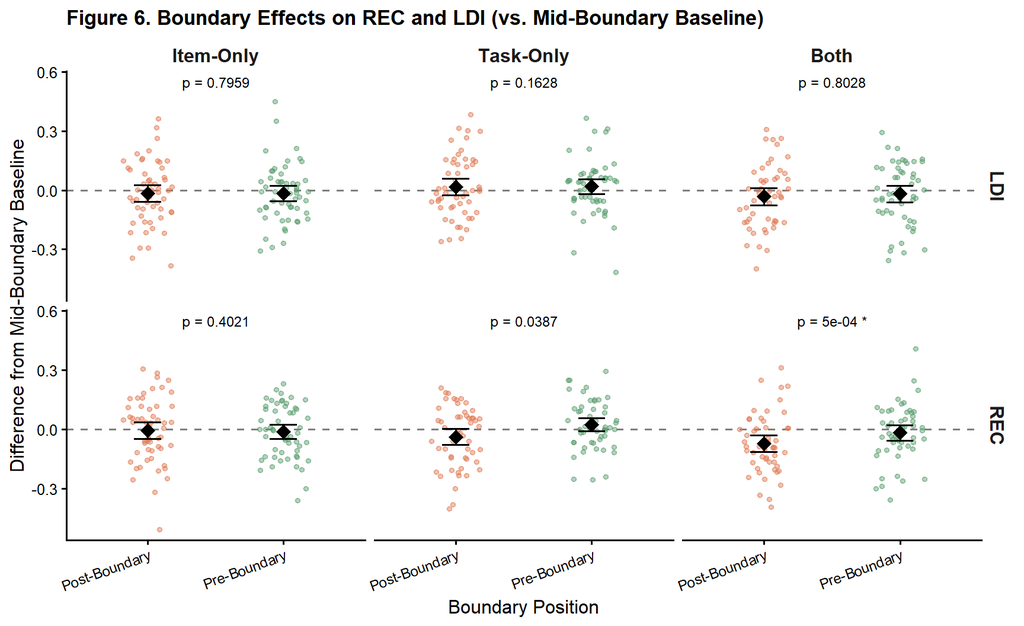

```r
sig_labels <- results_p1 %>%
  filter((Measure == "REC" & Position == "Post-Boundary") |
         (Measure == "LDI" & Position == "Pre-Boundary")) %>%
  mutate(label = paste0("p = ", p, ifelse(Sig == "Yes *", " *", "")),
         y_pos = 0.55,
         group = factor(Group, levels = c("Item-Only", "Task-Only", "Both"))) %>%
  filter(!is.na(group))

diff_long <- diff_scores %>%
  select(participant, group, boundary_pos, REC_diff, LDI_diff) %>%
  pivot_longer(cols = c(REC_diff, LDI_diff),
               names_to = "Measure", values_to = "Diff") %>%
  mutate(Measure = recode(Measure, "REC_diff" = "REC", "LDI_diff" = "LDI"))

fig6 <- diff_long %>%
  ggplot(aes(x = boundary_pos, y = Diff, colour = boundary_pos)) +
  geom_hline(yintercept = 0, linetype = "dashed", colour = "grey50") +
  geom_jitter(width = 0.18, alpha = 0.45, size = 1.3) +
  stat_summary(fun      = mean, geom = "point", shape = 18,
               size = 4, colour = "black") +
  stat_summary(fun.data = mean_se, fun.args = list(mult = 1.96),
               geom = "errorbar", width = 0.2, colour = "black") +
  geom_text(data = sig_labels,
          aes(x = 1.5, y = y_pos, label = label),
          colour = "black", size = 3.2, inherit.aes = FALSE,
          check_overlap = TRUE) +
  scale_colour_manual(values = bp_col) +
  facet_grid(Measure ~ group) +
  labs(x     = "Boundary Position",
       y     = "Difference from Mid-Boundary Baseline",
       title = "Figure 6. Boundary Effects on REC and LDI (vs. Mid-Boundary Baseline)") +
  theme_mst +
  theme(axis.text.x = element_text(angle = 20, hjust = 1, size = 9))

fig6
```

```r
ggsave(file.path(OUTPUT_DIR, "fig6_diff_scores_annotated.png"),
       fig6, width = 9, height = 5.5, dpi = 300)
```

**Both — H1a (Post-Boundary REC):** The Both group showed a mean difference of −0.072 (*SD* = 0.150), *t*(51) = −3.468, *p* = 0.0005, 95% CI [−∞, −0.037]. This result survives Bonferroni correction (α = 0.0125). Target recognition was reliably impaired for items encoded immediately after a compound event boundary, directly replicating the core finding of Morse et al. (2023). The effect size is moderate (Cohen’s *d* ≈ 0.48).

**Both — H1b (Pre-Boundary LDI):** Mean difference = −0.018 (*SD* = 0.153), *t*(51) = −0.859, *p* = 0.803. The result is in the wrong direction and clearly non-significant. The Pre-Boundary LDI enhancement observed by Morse et al. (2023) was not replicated. The most plausible explanation is the substantially reduced Foil pool in our design (30 vs. 120 in the original), which produces a much less stable per-participant LDI estimate.

**Item-Only:** Post-Boundary REC difference = −0.005, *t*(55) = −0.249, *p* = 0.402. Pre-Boundary LDI difference = −0.016, *t*(55) = −0.833, *p* = 0.796. Neither test approached significance, consistent with the null encoding RT result and confirming that stimulus class shifts alone do not constitute effective event boundaries.

The one-sample t-tests above established that the Both group shows a reliable Post-Boundary recognition impairment. Three questions naturally follow from this finding, which we address using the additional methods covered in the second part of the course.

**First**, the t-tests told us each group’s effect differs from zero, but they did not tell us whether the three groups differ *from each other*. If a compound boundary (Both) is truly necessary for the memory impairment, the Both group’s Post-Boundary REC should be significantly more negative than Item-Only and Task-Only — a question for ANOVA.

**Second**, group means can be pulled by a few participants with large effects. We should check whether the majority of individuals in the Both group show the expected direction — a question for a chi-squared test on the proportion of participants showing the predicted pattern.

**Third**, the LDI result was null overall, but with only 30 Foils the per-participant LDI estimate is noisy. If a Pre-Boundary pattern separation advantage exists at all, it should be most visible for the most similar lures (Bin 1–2) where hippocampal discrimination is most taxed. We can check this by decomposing LDI across the five similarity bins.

Additionally, because the boundary in the Both group is defined partly by a *switch in stimulus category* (Objects ↔︎ Scenes), it is worth asking whether Objects and Scenes are equally affected — or whether the category appearing immediately after the transition suffers more.

## 4.5 Does the Impairment Scale with Boundary Strength? (One-Way ANOVA)

The one-sample t-tests tested each group independently against zero. Here we directly compare the three groups’ Post-Boundary REC difference scores using a one-way ANOVA. Before running it, we check the two key assumptions: normality (Shapiro-Wilk) and homogeneity of variance (Levene’s). Depending on what those checks reveal, we use the standard ANOVA, Welch’s ANOVA (if variances are unequal), or Kruskal-Wallis (if normality is badly violated).

```r
post_diff <- diff_scores %>%
  filter(boundary_pos == "Post-Boundary") %>%
  select(participant, group, REC_diff, LDI_diff)

# Shapiro-Wilk per group
sw <- post_diff %>%
  group_by(group) %>%
  summarise(W = round(shapiro.test(REC_diff)$statistic, 3),
            p = round(shapiro.test(REC_diff)$p.value,   4),
            .groups = "drop") %>%
  mutate(Normal = ifelse(p >= ALPHA, "Yes", "No *"))

sw %>%
  kable(caption = "Table 4. Shapiro-Wilk normality test for Post-Boundary REC difference scores.",
        col.names = c("Group", "W", "p", "Normal?")) %>%
  kable_styling(bootstrap_options = c("striped", "hover"), full_width = FALSE) %>%
  row_spec(0, bold = TRUE, background = "#2E5FA3", color = "white") %>%
  row_spec(which(sw$Normal == "No *"), background = "#FDEBD0")
```

Table 4. Shapiro-Wilk normality test for Post-Boundary REC difference scores.

| Group | W | p | Normal? |
| --- | --- | --- | --- |
| Item-Only | 0.974 | 0.2545 | Yes |
| Task-Only | 0.956 | 0.0504 | Yes |
| Both | 0.980 | 0.5147 | Yes |

```r
levene_res <- post_diff %>% levene_test(REC_diff ~ group)

levene_res %>%
  mutate(across(where(is.numeric), ~round(., 4))) %>%
  kable(caption = "Table 5. Levene's test for homogeneity of variance across groups.") %>%
  kable_styling(bootstrap_options = c("striped", "hover"), full_width = FALSE) %>%
  row_spec(0, bold = TRUE, background = "#2E5FA3", color = "white")
```

Table 5. Levene’s test for homogeneity of variance across groups.

| df1 | df2 | statistic | p |
| --- | --- | --- | --- |
| 2 | 158 | 0.3262 | 0.7222 |

```r
normality_ok <- all(sw$p >= ALPHA)
levene_p     <- levene_res$p
```

```r
if (!normality_ok) {

  cat("Normality violated — using Kruskal-Wallis test.\n\n")
  kw <- post_diff %>% kruskal_test(REC_diff ~ group)
  kw %>%
    kable(caption = "Table 6. Kruskal-Wallis test: Post-Boundary REC across groups.") %>%
    kable_styling(bootstrap_options = c("striped","hover","bordered"), full_width = FALSE) %>%
    row_spec(0, bold = TRUE, background = "#2E5FA3", color = "white")

  if (kw$p < ALPHA) {
    cat("\nSignificant — running Dunn's post-hoc (Bonferroni-corrected).\n\n")
    post_diff %>%
      dunn_test(REC_diff ~ group, p.adjust.method = "bonferroni") %>%
      kable(caption = "Table 6b. Dunn's post-hoc comparisons.") %>%
      kable_styling(bootstrap_options = c("striped","hover","bordered"), full_width = FALSE) %>%
      row_spec(0, bold = TRUE, background = "#2E5FA3", color = "white")
  } else {
    cat("Not significant — no post-hoc comparisons performed.\n")
  }

} else if (levene_p < ALPHA) {

  cat("Variances unequal — using Welch's ANOVA.\n\n")
  welch <- post_diff %>% welch_anova_test(REC_diff ~ group)
  welch %>%
    kable(caption = "Table 6. Welch's ANOVA: Post-Boundary REC across groups.") %>%
    kable_styling(bootstrap_options = c("striped","hover","bordered"), full_width = FALSE) %>%
    row_spec(0, bold = TRUE, background = "#2E5FA3", color = "white")

  if (welch$p < ALPHA) {
    cat("\nSignificant — running Games-Howell post-hoc.\n\n")
    post_diff %>%
      games_howell_test(REC_diff ~ group) %>%
      kable(caption = "Table 6b. Games-Howell post-hoc comparisons.") %>%
      kable_styling(bootstrap_options = c("striped","hover","bordered"), full_width = FALSE) %>%
      row_spec(0, bold = TRUE, background = "#2E5FA3", color = "white")
  } else {
    cat("Not significant — no post-hoc comparisons performed.\n")
  }

} else {

  cat("Assumptions met — running standard one-way ANOVA.\n\n")
  aov_res <- post_diff %>% anova_test(REC_diff ~ group)
  get_anova_table(aov_res) %>%
    kable(caption = "Table 6. One-way ANOVA: Post-Boundary REC across groups.") %>%
    kable_styling(bootstrap_options = c("striped","hover","bordered"), full_width = FALSE) %>%
    row_spec(0, bold = TRUE, background = "#2E5FA3", color = "white")

  if (as.data.frame(get_anova_table(aov_res))$p < ALPHA) {
    cat("\nSignificant — running Tukey HSD post-hoc.\n\n")
    post_diff %>%
      tukey_hsd(REC_diff ~ group) %>%
      select(group1, group2, estimate, conf.low, conf.high, p.adj, p.adj.signif) %>%
      mutate(across(where(is.numeric), ~round(., 4))) %>%
      kable(caption = "Table 6b. Tukey HSD post-hoc comparisons.") %>%
      kable_styling(bootstrap_options = c("striped","hover","bordered"), full_width = FALSE) %>%
      row_spec(0, bold = TRUE, background = "#2E5FA3", color = "white")
  } else {
    cat("Not significant — no post-hoc comparisons performed.\n")
  }
}
```

```
## Assumptions met — running standard one-way ANOVA.
##
## Not significant — no post-hoc comparisons performed.
```

### 4.5.1 Figure 7: Post-Boundary REC by Group

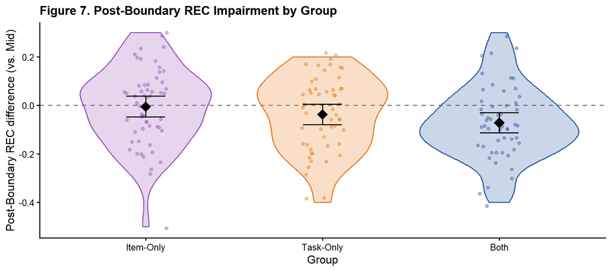

Figure 7. Post-Boundary REC difference scores by group. Diamonds = means ± 95% CI. Dashed line = zero. A more negative score means greater Post-Boundary impairment.

```r
fig7 <- post_diff %>%
  ggplot(aes(x = group, y = REC_diff, fill = group, colour = group)) +
  geom_hline(yintercept = 0, linetype = "dashed", colour = "grey50") +
  geom_violin(alpha = 0.25, trim = TRUE) +
  geom_jitter(width = 0.12, alpha = 0.40, size = 1.4) +
  stat_summary(fun      = mean, geom = "point",
               shape = 18, size = 5, colour = "black") +
  stat_summary(fun.data = mean_cl_normal, geom = "errorbar",
               width = 0.22, colour = "black") +
  scale_fill_manual(values   = grp_col) +
  scale_colour_manual(values = grp_col) +
  labs(x     = "Group",
       y     = "Post-Boundary REC difference (vs. Mid)",
       title = "Figure 7. Post-Boundary REC Impairment by Group") +
  theme_mst

fig7
```

```r
ggsave(file.path(OUTPUT_DIR, "fig7_anova_rec.png"), fig7, width = 7, height = 4, dpi = 300)
```

The ANOVA tests whether group *means* differ. But a mean can be shifted by a small number of participants with large effects. To check whether the Post-Boundary impairment reflects a broad, consistent pattern, we ask: in the Both group, do the *majority* of individual participants show Post-Boundary REC lower than Pre-Boundary REC (the expected direction)? We frame this as a chi-squared goodness-of-fit test against a 50/50 null — if direction is random, half should show the expected pattern and half should not.

```r
direction_df <- diff_scores %>%
  select(participant, group, boundary_pos, REC_diff) %>%
  pivot_wider(names_from = boundary_pos, values_from = REC_diff) %>%
  mutate(expected_dir = `Post-Boundary` < `Pre-Boundary`) %>%
  filter(!is.na(expected_dir))

dir_counts <- direction_df %>%
  group_by(group) %>%
  summarise(N          = n(),
            N_expected = sum(expected_dir),
            Pct        = round(100 * N_expected / N, 1),
            .groups    = "drop")

chisq_res <- dir_counts %>%
  rowwise() %>%
  mutate(
    chi2 = round(chisq.test(c(N_expected, N - N_expected), p = c(0.5, 0.5))$statistic, 3),
    p    = round(chisq.test(c(N_expected, N - N_expected), p = c(0.5, 0.5))$p.value,   4),
    Sig  = ifelse(p < ALPHA, "Yes *", "No")
  ) %>%
  ungroup()

chisq_res %>%
  select(group, N, N_expected, Pct, chi2, p, Sig) %>%
  kable(caption = "Table 7. Chi-squared goodness-of-fit: proportion showing expected REC direction vs. 50% chance.",
        col.names = c("Group", "N", "N Expected Direction", "%", "χ²(1)", "p", "Sig.")) %>%
  kable_styling(bootstrap_options = c("striped", "hover", "bordered"), full_width = FALSE) %>%
  row_spec(0, bold = TRUE, background = "#2E5FA3", color = "white") %>%
  row_spec(which(chisq_res$Sig == "Yes *"), background = "#E8F5E9", bold = TRUE)
```

Table 7. Chi-squared goodness-of-fit: proportion showing expected REC direction vs. 50% chance.

| Group | N | N Expected Direction | % | χ²(1) | p | Sig. |
| --- | --- | --- | --- | --- | --- | --- |
| Item-Only | 56 | 19 | 33.9 | 5.786 | 0.0162 | Yes * |
| Task-Only | 53 | 32 | 60.4 | 2.283 | 0.1308 | No |
| Both | 52 | 31 | 59.6 | 1.923 | 0.1655 | No |

### 4.5.2 Figure 8: Direction Proportions by Group

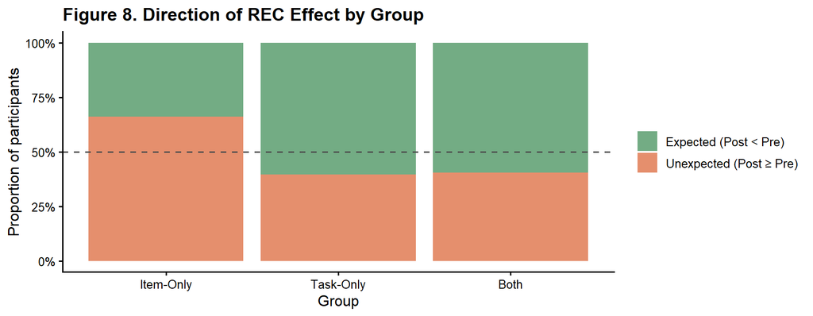

Figure 8. Proportion of participants showing Post-Boundary REC below Pre-Boundary (green = expected; orange = unexpected). Dashed line = 50% chance.

```r
dir_long <- dir_counts %>%
  mutate(N_unexpected = N - N_expected) %>%
  pivot_longer(cols = c(N_expected, N_unexpected),
               names_to = "Direction", values_to = "Count") %>%
  mutate(Direction  = recode(Direction,
                             "N_expected"   = "Expected (Post < Pre)",
                             "N_unexpected" = "Unexpected (Post ≥ Pre)"),
         Proportion = Count / N)

fig8 <- dir_long %>%
  ggplot(aes(x = group, y = Proportion, fill = Direction)) +
  geom_col(alpha = 0.85) +
  geom_hline(yintercept = 0.5, linetype = "dashed", colour = "grey30") +
  scale_fill_manual(values = c("Expected (Post < Pre)"   = "#5A9E6F",
                               "Unexpected (Post ≥ Pre)" = "#E07B54")) +
  scale_y_continuous(labels = scales::percent_format()) +
  labs(x = "Group", y = "Proportion of participants", fill = NULL,
       title = "Figure 8. Direction of REC Effect by Group") +
  theme_classic(base_size = 12) +
  theme(plot.title = element_text(face = "bold"), legend.position = "right")

fig8
```

```r
ggsave(file.path(OUTPUT_DIR, "fig8_direction.png"), fig8, width = 7, height = 3.5, dpi = 300)
```

The chi-squared results reveal an unexpected pattern. In the Both group, only 31 of 52 participants (59.6%) showed Post-Boundary REC below Pre-Boundary REC (the expected direction), which did not significantly differ from chance (χ²(1) = 1.923, *p* = 0.166). Similarly, Task-Only showed 60.4% in the expected direction, also non-significant (χ²(1) = 2.283, *p* = 0.131). Strikingly, Item-Only showed the opposite pattern — only 33.9% showed the expected direction, which *was* significantly below chance (χ²(1) = 5.786, *p* = 0.016), indicating that participants in the Item-Only group were actually more likely to show *better* Post-Boundary than Pre-Boundary recognition. This is consistent with the absence of a genuine boundary in Item-Only — without a perceived boundary, there is no systematic encoding disruption and the directional pattern is effectively random or slightly reversed. Taken together, the chi-squared results suggest that while the Both group mean difference is reliably non-zero (as shown by the Phase 1 t-test), the impairment is not sufficiently large to shift the majority of individuals past the critical threshold, pointing to substantial individual variability in susceptibility to boundary-related encoding disruption.

Having confirmed that the Both group shows a reliable Post-Boundary impairment, we now ask whether this impairment is the same for both Object and Scene stimuli. This matters because the boundary in the Both group is defined partly by a switch *between* these categories. If the impairment simply reflects attentional disruption at the transition point, it should be equally strong for Objects and Scenes. If instead one category is more affected — perhaps the category appearing at the leading edge of the new event — we would see an interaction between boundary position and stimulus class.

We test this with a 2 × 2 repeated-measures ANOVA (boundary position: Post vs. Pre × stimulus class: Object vs. Scene) within the Both group. Both factors are within-subject because each participant sees both Objects and Scenes at each boundary position.

```r
scores_by_type <- test_data %>%
  filter(group == "Both", stim_type == "Target",
         !is.na(boundary_pos), img_type != "Unknown") %>%
  group_by(participant, boundary_pos, img_type) %>%
  summarise(p_old_target = mean(response == "old", na.rm = TRUE), .groups = "drop") %>%
  left_join(foil_rates %>% filter(group == "Both"), by = "participant") %>%
  mutate(REC = p_old_target - p_old_foil)

# Descriptive
scores_by_type %>%
  group_by(boundary_pos, img_type) %>%
  summarise(N      = n(),
            M_REC  = round(mean(REC, na.rm = TRUE), 3),
            SD_REC = round(sd(REC,   na.rm = TRUE), 3),
            .groups = "drop") %>%
  kable(caption = "Table 8. Mean REC by boundary position and stimulus class (Both group).",
        col.names = c("Boundary Position", "Stimulus Class", "N", "M (REC)", "SD (REC)")) %>%
  kable_styling(bootstrap_options = c("striped", "hover", "bordered"), full_width = FALSE) %>%
  row_spec(0, bold = TRUE, background = "#2E5FA3", color = "white")
```

Table 8. Mean REC by boundary position and stimulus class (Both group).

| Boundary Position | Stimulus Class | N | M (REC) | SD (REC) |
| --- | --- | --- | --- | --- |
| Post-Boundary | Object | 52 | 0.563 | 0.196 |
| Post-Boundary | Scene | 52 | 0.534 | 0.213 |
| Mid-Boundary | Object | 52 | 0.685 | 0.178 |
| Mid-Boundary | Scene | 52 | 0.553 | 0.241 |
| Pre-Boundary | Object | 52 | 0.666 | 0.183 |
| Pre-Boundary | Scene | 52 | 0.546 | 0.205 |

```r
# Normality check per cell
sw_rm <- scores_by_type %>%
  filter(boundary_pos != "Mid-Boundary") %>%
  group_by(boundary_pos, img_type) %>%
  summarise(W = round(shapiro.test(REC)$statistic, 3),
            p = round(shapiro.test(REC)$p.value,   4),
            .groups = "drop")

sw_rm %>%
  kable(caption = "Table 9. Shapiro-Wilk checks per cell of the repeated-measures design.",
        col.names = c("Boundary Position", "Stimulus Class", "W", "p")) %>%
  kable_styling(bootstrap_options = c("striped", "hover"), full_width = FALSE) %>%
  row_spec(0, bold = TRUE, background = "#2E5FA3", color = "white") %>%
  row_spec(which(sw_rm$p < ALPHA), background = "#FDEBD0")
```

Table 9. Shapiro-Wilk checks per cell of the repeated-measures design.

| Boundary Position | Stimulus Class | W | p |
| --- | --- | --- | --- |
| Post-Boundary | Object | 0.948 | 0.0230 |
| Post-Boundary | Scene | 0.978 | 0.4446 |
| Pre-Boundary | Object | 0.925 | 0.0029 |
| Pre-Boundary | Scene | 0.987 | 0.8245 |

```r
# 2×2 repeated-measures ANOVA
rm_data <- scores_by_type %>%
  filter(boundary_pos != "Mid-Boundary") %>%
  mutate(boundary_pos = droplevels(boundary_pos))

rm_anova <- rm_data %>%
  anova_test(dv = REC, wid = participant, within = c(boundary_pos, img_type))

get_anova_table(rm_anova) %>%
  kable(caption = "Table 10. Repeated-measures ANOVA: boundary position × stimulus class on REC (Both group).") %>%
  kable_styling(bootstrap_options = c("striped", "hover", "bordered"), full_width = FALSE) %>%
  row_spec(0, bold = TRUE, background = "#2E5FA3", color = "white")
```

Table 10. Repeated-measures ANOVA: boundary position × stimulus class on REC (Both group).

Effect

DFn

DFd

F

p

p<.05

ges

boundary_pos

1

51

7.959

0.007

0.021

img_type

1

51

7.416

0.009

0.035

boundary_pos:img_type

1

51

5.995

0.018

0.013

```r
# If interaction is significant, decompose it
interaction_p <- as.data.frame(get_anova_table(rm_anova))[
  as.data.frame(get_anova_table(rm_anova))[["Effect"]] == "boundary_pos:img_type", "p"]

if (interaction_p < ALPHA) {
  cat("\nSignificant interaction — simple effect of boundary position within each stimulus class.\n\n")
  rm_data %>%
    group_by(img_type) %>%
    t_test(REC ~ boundary_pos, paired = TRUE, p.adjust.method = "bonferroni") %>%
    kable(caption = "Table 10b. Simple effects: Post vs. Pre-Boundary within each stimulus class.") %>%
    kable_styling(bootstrap_options = c("striped","hover","bordered"), full_width = FALSE) %>%
    row_spec(0, bold = TRUE, background = "#2E5FA3", color = "white")
} else {
  cat("Interaction not significant — boundary position effect does not differ between Objects and Scenes.\n")
}
```

```
##
## Significant interaction — simple effect of boundary position within each stimulus class.
```

Table 10b. Simple effects: Post vs. Pre-Boundary within each stimulus class.

| img_type | .y. | group1 | group2 | n1 | n2 | statistic | df | p |
| --- | --- | --- | --- | --- | --- | --- | --- | --- |
| Object | REC | Post-Boundary | Pre-Boundary | 52 | 52 | -3.6299600 | 51 | 0.000657 |
| Scene | REC | Post-Boundary | Pre-Boundary | 52 | 52 | -0.4248311 | 51 | 0.673000 |

### 4.5.3 Figure 9: REC by Boundary Position and Stimulus Class

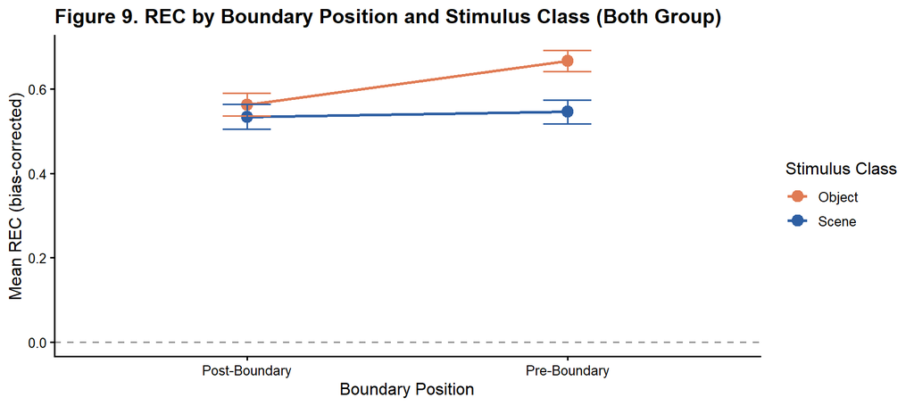

Figure 9. Mean REC for Objects and Scenes at Post- and Pre-Boundary positions in the Both group. Error bars = ±1 SE.

```r
obj_scene_desc <- scores_by_type %>%
  filter(boundary_pos != "Mid-Boundary") %>%
  group_by(boundary_pos, img_type) %>%
  summarise(M  = mean(REC, na.rm = TRUE),
            SE = sd(REC,   na.rm = TRUE) / sqrt(n()),
            .groups = "drop")

fig9 <- obj_scene_desc %>%
  ggplot(aes(x = boundary_pos, y = M,
             colour = img_type, group = img_type)) +
  geom_hline(yintercept = 0, linetype = "dashed", colour = "grey60") +
  geom_line(linewidth = 0.9) +
  geom_point(size = 3.5) +
  geom_errorbar(aes(ymin = M - SE, ymax = M + SE), width = 0.15) +
  scale_colour_manual(values = c("Object" = "#E07B54", "Scene" = "#2E5FA3"),
                      name = "Stimulus Class") +
  labs(x     = "Boundary Position",
       y     = "Mean REC (bias-corrected)",
       title = "Figure 9. REC by Boundary Position and Stimulus Class (Both Group)") +
  theme_classic(base_size = 12) +
  theme(plot.title = element_text(face = "bold"), legend.position = "right")

fig9
```

```r
ggsave(file.path(OUTPUT_DIR, "fig9_obj_scene.png"), fig9, width = 6.5, height = 4, dpi = 300)
```

Normality was violated for Objects at both boundary positions (Post-Boundary Object: *W* = 0.948, *p* = 0.023; Pre-Boundary Object: *W* = 0.925, *p* = 0.003), while Scenes were normal in both cells (*p* > 0.44). Despite the violation in the Object cells, the repeated-measures ANOVA is reasonably robust to moderate normality violations, and results are interpreted with appropriate caution.

The one-sample t-test for Pre-Boundary LDI in Phase 1 was null. Before concluding there is no Pre-Boundary pattern separation advantage, it is worth decomposing LDI across the five similarity bins. With only 30 Foils in our design, the overall LDI index is estimated from very few trials per participant — each bin has roughly 4 lure trials per boundary position — which substantially degrades reliability. However, if a Pre-Boundary encoding advantage exists, it should be largest for Bin 1 (most similar to target), where hippocampal pattern separation is most critically needed.

We plot mean LDI across bins and boundary positions first to inspect the trend, then test whether a boundary position × bin interaction exists using a mixed ANOVA (between: boundary position Post vs. Pre; within: lure bin 1–5) in the Both group.

```r
bin_ldi <- test_data %>%
  filter(group == "Both", stim_type == "Lure",
         !is.na(boundary_pos), !is.na(lure_bin)) %>%
  group_by(participant, boundary_pos, lure_bin) %>%
  summarise(p_sim = mean(response == "similar", na.rm = TRUE), .groups = "drop") %>%
  left_join(foil_rates %>% filter(group == "Both"), by = "participant") %>%
  mutate(LDI_bin  = p_sim - p_sim_foil,
         lure_bin = factor(lure_bin))

# Descriptive: mean LDI by bin and boundary position
bin_desc <- bin_ldi %>%
  filter(boundary_pos != "Mid-Boundary") %>%
  group_by(boundary_pos, lure_bin) %>%
  summarise(M_LDI = round(mean(LDI_bin, na.rm = TRUE), 3),
            SE    = round(sd(LDI_bin,   na.rm = TRUE) / sqrt(n()), 3),
            .groups = "drop")

bin_desc %>%
  pivot_wider(names_from = lure_bin,
              values_from = c(M_LDI, SE),
              names_glue = "Bin{lure_bin}_{.value}") %>%
  kable(caption = "Table 11. Mean LDI per similarity bin and boundary position (Both group). Bin 1 = most similar.") %>%
  kable_styling(bootstrap_options = c("striped", "hover", "bordered"), full_width = TRUE) %>%
  row_spec(0, bold = TRUE, background = "#2E5FA3", color = "white")
```

Table 11. Mean LDI per similarity bin and boundary position (Both group). Bin 1 = most similar.

| boundary_pos | Bin1_M_LDI | Bin2_M_LDI | Bin3_M_LDI | Bin4_M_LDI | Bin5_M_LDI | Bin1_SE | Bin2_SE | Bin3_SE | Bin4_SE | Bin5_SE |
| --- | --- | --- | --- | --- | --- | --- | --- | --- | --- | --- |
| Post-Boundary | 0.124 | 0.291 | 0.248 | 0.345 | 0.291 | 0.036 | 0.048 | 0.037 | 0.042 | 0.039 |
| Pre-Boundary | 0.211 | 0.283 | 0.195 | 0.312 | 0.318 | 0.044 | 0.042 | 0.042 | 0.040 | 0.048 |

### 4.5.4 Figure 10: LDI across Similarity Bins

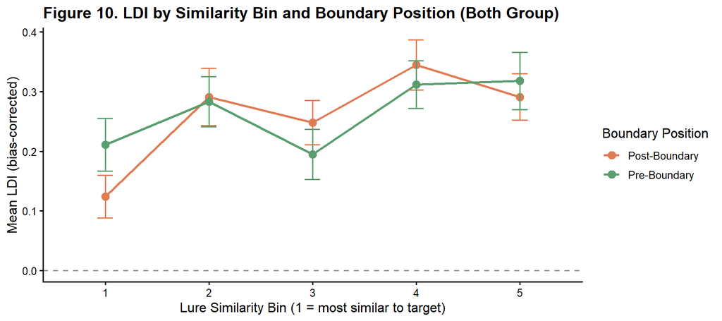

Figure 10. Mean LDI by lure similarity bin and boundary position (Both group). Bin 1 = most similar (hardest pattern separation); Bin 5 = least similar (easiest). A divergence at Bin 1–2 would support a Pre-Boundary pattern separation advantage. Error bars = ±1 SE.

```r
fig10 <- bin_desc %>%
  ggplot(aes(x = lure_bin, y = M_LDI,
             colour = boundary_pos, group = boundary_pos)) +
  geom_hline(yintercept = 0, linetype = "dashed", colour = "grey60") +
  geom_line(linewidth = 0.9) +
  geom_point(size = 3) +
  geom_errorbar(aes(ymin = M_LDI - SE, ymax = M_LDI + SE), width = 0.15) +
  scale_colour_manual(values = c("Post-Boundary" = "#E07B54",
                                 "Pre-Boundary"  = "#5A9E6F"),
                      name = "Boundary Position") +
  labs(x     = "Lure Similarity Bin (1 = most similar to target)",
       y     = "Mean LDI (bias-corrected)",
       title = "Figure 10. LDI by Similarity Bin and Boundary Position (Both Group)") +
  theme_classic(base_size = 12) +
  theme(plot.title = element_text(face = "bold"), legend.position = "right")

fig10
```

```r
ggsave(file.path(OUTPUT_DIR, "fig10_bin_ldi.png"), fig10, width = 7, height = 4, dpi = 300)
```

### 4.5.5 Assumption Checks: Normality and Sphericity

Before running the mixed ANOVA, we verify two assumptions. First, normality of the within-cell LDI distributions (Shapiro-Wilk per bin × boundary position cell). Second, and most importantly for a repeated-measures design with 5 lure bins, **sphericity** — the assumption that the variances of all pairwise differences between the within-subject levels (bins) are equal. With 5 bins there are 10 such pairs, so sphericity cannot be assumed automatically (unlike the 2×2 RM-ANOVA above which had only 2 levels per factor). Mauchly’s test is used to evaluate this. If violated, Greenhouse-Geisser (GG) correction is applied to the degrees of freedom. `rstatix::anova_test()` computes and applies this automatically; here we print the result explicitly.

```r
bin_anova_data <- bin_ldi %>%
  filter(boundary_pos != "Mid-Boundary") %>%
  mutate(boundary_pos = droplevels(boundary_pos))

# Normality check per bin × boundary position cell
sw_bin <- bin_anova_data %>%
  group_by(boundary_pos, lure_bin) %>%
  summarise(W = round(shapiro.test(LDI_bin)$statistic, 3),
            p = round(shapiro.test(LDI_bin)$p.value,   4),
            .groups = "drop") %>%
  mutate(Normal = ifelse(p >= ALPHA, "Yes", "No *"))

sw_bin %>%
  kable(caption = "Table SW2. Shapiro-Wilk normality tests per bin × boundary position cell (Both group).",
        col.names = c("Boundary Position", "Lure Bin", "W", "p", "Normal?")) %>%
  kable_styling(bootstrap_options = c("striped", "hover", "bordered"), full_width = FALSE) %>%
  row_spec(0, bold = TRUE, background = "#2E5FA3", color = "white") %>%
  row_spec(which(sw_bin$Normal == "No *"), background = "#FDEBD0")
```

Table SW2. Shapiro-Wilk normality tests per bin × boundary position cell (Both group).

| Boundary Position | Lure Bin | W | p | Normal? |
| --- | --- | --- | --- | --- |
| Post-Boundary | 1 | 0.971 | 0.2537 | Yes |
| Post-Boundary | 2 | 0.973 | 0.3115 | Yes |
| Post-Boundary | 3 | 0.986 | 0.8120 | Yes |
| Post-Boundary | 4 | 0.966 | 0.1576 | Yes |
| Post-Boundary | 5 | 0.976 | 0.3731 | Yes |
| Pre-Boundary | 1 | 0.985 | 0.7341 | Yes |
| Pre-Boundary | 2 | 0.973 | 0.2848 | Yes |
| Pre-Boundary | 3 | 0.977 | 0.4040 | Yes |
| Pre-Boundary | 4 | 0.976 | 0.3659 | Yes |
| Pre-Boundary | 5 | 0.967 | 0.1621 | Yes |

```r
n_bin_violations <- sum(sw_bin$Normal == "No *")
if (n_bin_violations == 0) {
  cat("> Normality satisfied in all cells. Proceeding with mixed ANOVA.\n")
} else {
  cat(paste0("> ", n_bin_violations, " cell(s) show normality violation (highlighted). ",
             "With n ≥ 52, the mixed ANOVA is robust to moderate violations via CLT.\n"))
}
```

```
## > Normality satisfied in all cells. Proceeding with mixed ANOVA.
```

```r
# Run mixed ANOVA — rstatix automatically computes Mauchly's and applies GG correction
bin_anova <- bin_anova_data %>%
  anova_test(dv      = LDI_bin,
             wid     = participant,
             between = boundary_pos,
             within  = lure_bin)
# Extract and display Mauchly's sphericity test result explicitly
mauchly_result <- bin_anova$`Mauchly's Test for Sphericity`

if (!is.null(mauchly_result)) {
  mauchly_result %>%
    mutate(across(where(is.numeric), ~round(., 4))) %>%
    kable(caption = "Table SW3. Mauchly's test of sphericity for the within-subject factor (lure bin).") %>%
    kable_styling(bootstrap_options = c("striped", "hover", "bordered"), full_width = FALSE) %>%
    row_spec(0, bold = TRUE, background = "#2E5FA3", color = "white")

  mauchly_p <- mauchly_result$p[mauchly_result$Effect == "lure_bin"]
  if (!is.na(mauchly_p) && mauchly_p < ALPHA) {
    cat(paste0("\n> Mauchly's test significant (p = ", round(mauchly_p, 4),
               ") — sphericity violated. Greenhouse-Geisser correction applied automatically.\n"))
  } else {
    cat(paste0("\n> Mauchly's test not significant (p = ", round(mauchly_p, 4),
               ") — sphericity assumption holds. Standard df used.\n"))
  }
} else {
  cat("> Mauchly's test result not available in this rstatix version — GG correction applied by default.\n")
}
```

```
##
## > Mauchly's test not significant (p = 0.549) — sphericity assumption holds. Standard df used.
```

```r
get_anova_table(bin_anova) %>%
  kable(caption = "Table 12. Mixed ANOVA: boundary position (between) × lure bin (within) on LDI (Both group).") %>%
  kable_styling(bootstrap_options = c("striped", "hover", "bordered"), full_width = FALSE) %>%
  row_spec(0, bold = TRUE, background = "#2E5FA3", color = "white")
```

Table 12. Mixed ANOVA: boundary position (between) × lure bin (within) on LDI (Both group).

Effect

DFn

DFd

F

p

p<.05

ges

boundary_pos

1

94

0.083

7.74e-01

0.000372

lure_bin

4

376

6.413

5.32e-05

0.038000

boundary_pos:lure_bin

4

376

1.317

2.63e-01

0.008000

```r
interaction_bin_p <- as.data.frame(get_anova_table(bin_anova))[
  as.data.frame(get_anova_table(bin_anova))[["Effect"]] == "boundary_pos:lure_bin", "p"]

if (interaction_bin_p < ALPHA) {
  cat("\nSignificant interaction — simple effect of boundary position at each bin.\n\n")
  bin_anova_data %>%
    group_by(lure_bin) %>%
    t_test(LDI_bin ~ boundary_pos, p.adjust.method = "bonferroni") %>%
    select(lure_bin, group1, group2, statistic, df, p, p.adj, p.adj.signif) %>%
    kable(caption = "Table 12b. Simple effect of boundary position within each lure bin.") %>%
    kable_styling(bootstrap_options = c("striped","hover","bordered"), full_width = FALSE) %>%
    row_spec(0, bold = TRUE, background = "#2E5FA3", color = "white")
} else {
  cat("Interaction not significant (p =", round(interaction_bin_p, 4), ") —",
      "no bin-specific boundary effect on LDI detected.\n")
}
```

```
## Interaction not significant (p = 0.263 ) — no bin-specific boundary effect on LDI detected.
```